# Random Ducks in a Circle

Lyle Liu

2025-12-04

## Problem Description

We investigate the probability that `n` ducks randomly placed in a circle happen to fall in a semicircle.

## Theoretical Proof via Event Approach

Let us define events $A_i$ for $i = 1, \dots, n$ as follows:

> $A_i$: all ducks fall in the semicircle whose left endpoint is at duck $i$.

### Step 1: Probability of a single event

By symmetry, each $A_i$ has the same probability:

$$\Pr(A_i) = \frac{1}{2^{n-1}}.$$

### Step 2: Mutual exclusivity of events

To see that the events $A_i$ are mutually exclusive, note that:

- A semicircle is defined by its leftmost duck.
- If all ducks are contained in the semicircle starting at duck $i$, then **no other duck can serve as the left endpoint for a semicircle containing all ducks**.
- Therefore, if $A_i$ occurs, none of the other $A_j$ ($j \neq i$) can occur simultaneously.

Formally:

$$A_i \cap A_j = \emptyset, \quad \forall i \neq j.$$

### Step 3: Total probability

Since the events are mutually exclusive, the probability that all ducks fall in some semicircle is:

$$P_n = \Pr\left(\bigcup_{i=1}^{n} A_i \right) = \sum_{i=1}^{n} \Pr(A_i) =
n \cdot \frac{1}{2^{n-1}}.$$

Thus, the final theoretical result is:

$$\boxed{P_n = \frac{n}{2^{n-1}}}.$$

# Monte Carlo Simulation

In four ducks case, as shown above the probability should be $\frac{1}{2}$.

```r
source("../src/utils.r")
source("../src/monte_carlo.r")
```

```r
set.seed(123)
monte_carlo(n = 4, trials = 50000)
```

```
## [1] 0.50384
```

The simulated result aligns with our calculation.

Here we visualize the convergence of probability as the # of trials increases:

```r
source("../src/conv_by_trials.r")
```

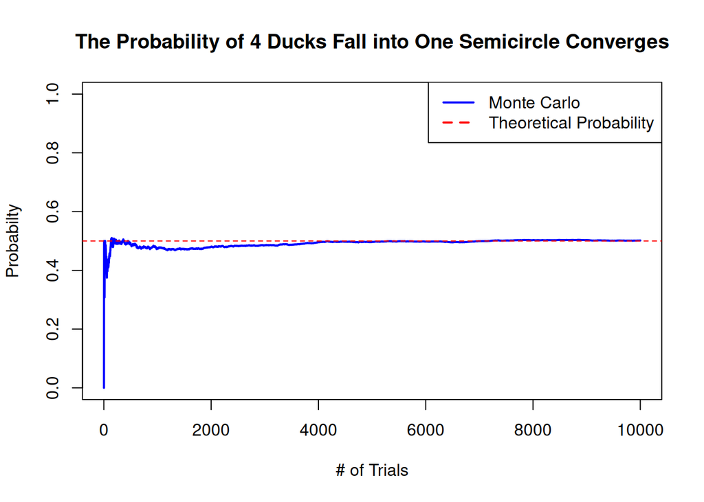

And the probability decreases when there are more ducks fall into the circle:

```r
source("../src/prob_by_numb.r")
```

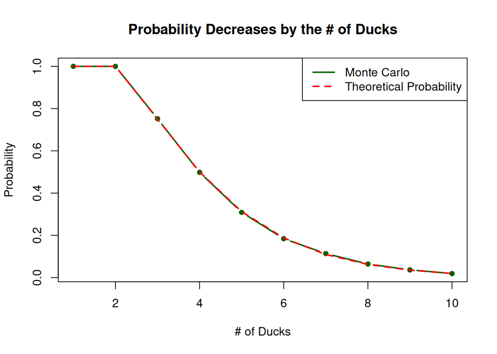